# Predicting the Roast of Coffee Using tf-idf and Doc2vec

By: Gabija Arciskeviciute

```python
import requests
import json
import matplotlib.pyplot as plt
```

[figure not shown]

## Introduction

The goal of this project is to compare the effectiveness of tf-idf and Doc2vec on differentiating different roasts of coffee from a short description. My reason for pursuing this project is that I have always looked at the different coffees in grocery stores and coffee shops and noticed that the descriptions seem to give away what kind of roast the coffee is. For example, seeing words like rich or chocolate usually indicate a darker roast while words like fruit indicate a lighter roast. In this project, my goal is to find out whether that is a generalization, or whether you can reliably predict a coffee roast based on the description and flavor profiles of the coffee.

## Gather the Data

The first thing I had to do was gather data. I am sure that there is some dataset already curated online, but I really wanted to scrape the data myself. I looked at a bunch of different coffee sites and was getting quite discouraged since each of them only had 10-15 different coffees. Eventually, though, I realized that a coffee subscription service probably has the most different and unique coffees. I found www.mistobox.com which has over 600 different coffees available! That is perfect for this project, the only thing that I have to do is get the data in here now.

I originally planned to use BeautifulSoup4 to scrape the website, however, I quickly noticed an issue. When loading the page on a browser (or in bs4) it only loaded 12 different coffees at a time, and in order to load the rest, you had to scroll down. The solution to this problem could have been something like selenium, which you can control like a browser (i.e. make it scroll down and load all the coffees). However, I have never used selenium from within a jupyter notebook and it also is a little heavy-handed for a data scraping task like this. I then checked out the network tab of Google Chrome and noticed that when you scrolled down, it was making an API call. This seemed like a request that I could make using the python requests library. Below is the code that I eventually got to work for scraping the data.

```python
# Url of the request from Google Chrome network tab
url = 'https://92nybnyamc-dsn.algolia.net/1/indexes/coffee/query?x-algolia-agent=Algolia%20for%20JavaScript%20(3.35.1)%3B%20Browser&x-algolia-application-id=92NYBNYAMC&x-algolia-api-key=197eb4b9981532b5a33639b6b70c8a59'

# Headers from network tab
headers = {
    "accept": "application/json",
    "accept-language": "en-US,en;q=0.9",
    "content-type": "application/x-www-form-urlencoded",
    "sec-ch-ua": "\" Not A;Brand\";v=\"99\", \"Chromium\";v=\"96\", \"Google Chrome\";v=\"96\"",
    "sec-ch-ua-mobile": "?0",
    "sec-ch-ua-platform": "\"Windows\"",
    "sec-fetch-dest": "empty",
    "sec-fetch-mode": "cors",
    "sec-fetch-site": "cross-site"
}

# Needed a session to have the correct referrer
s = requests.Session()
s.headers.update({'referer': "https://www.mistobox.com/"})

# Store data and labels in arrays with matching indices
data = []
labels = []

# There are 55 "pages" of coffee so we call 55 times
for i in range(1, 55):
    # Make a post request
    resp = s.post(url, data="{\"params\":\"query=&filters=searchable%3Atrue&hitsPerPage=12&page=" + str(i) + "&facets=%5B%22*%22%5D\"}", headers=headers)
    for hit in resp.json()['hits']:
        # Format the label and the description nicely
        desc = hit['short_description'].replace(',', '')
        flavors = ' '.join([x.lower() for x in hit['flavors']])
        total_data = desc + ' ' + flavors

        lab = '-'.join([x.lower() for x in hit['roasts']])

        # Only add data if both label and description are present
        if total_data != '' and lab != '':
            data.append(total_data)
            labels.append(lab)
```

Let's take a look at how many examples we got and an example of the description and the label.

```python
print(len(labels),len(data))
print(data[0] + ' -> ' + labels[0])
```

```
634 634
tangerine passion fruit vibrant fruity -> light-medium
```

We got 634 examples of coffees which is quite a lot! Also so far it seems like my idea that fruit corresponding to a lighter roast of coffee is holding up so far! The only way to really be sure about that though is to do some exploratory data analysis. Unfortunately, I don't think that there is much feature engineering to do for either of the models that I am using, especially since the data already looks nice for those two models. However, we can still make some interesting conclusions about the data from looking at trends!

## Exploratory Data Analysis

```python
# Function to generate frequency graph of different words for roast of coffee
def generate_graph_for_words(words):
    graph = [0, 0, 0, 0, 0]
    possible_labels = ['light', 'light-medium', 'medium', 'medium-dark', 'dark']

    # Look through descriptions and labels and increment count for label if word is in description
    for x, y in zip(data, labels):
        for word in words:
            if word in x:
                graph[possible_labels.index(y)] += 1
                break

    # label axis and plot graoh
    fig = plt.figure(figsize=(20,10))
    plt.bar(possible_labels,graph)
    plt.ylabel(f'Frequency of Word{"s" if len(words) > 1 else ""} {", ".join([x.capitalize() for x in words])}', fontsize=20)
    plt.xlabel('Roast of Coffee', fontsize=20)
    plt.title(f'Frequency of Word{"s" if len(words) > 1 else ""} {", ".join([x.capitalize() for x in words])} vs Roast of Coffee', fontsize=25)
    plt.show()
```

The function above essentially counts how many coffee descriptions contain a specific word, partitioned by the roast of the coffee. This is a very important function as it can help to show if my predictions about different words and their trends are true.

Now, we are going to try the function on some different common coffee words.

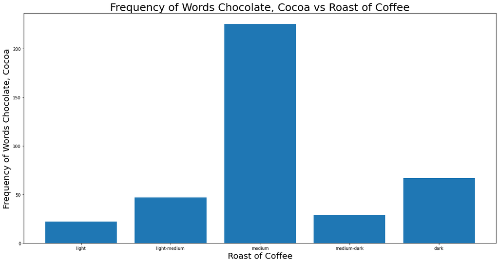

```python
generate_graph_for_words(['chocolate', 'cocoa'])
```

This is an interesting result actually, I really expected the words chocolate and cocoa to correspond to darker roasts of coffee, but maybe the local coffee shops around me have skewed my expectations.

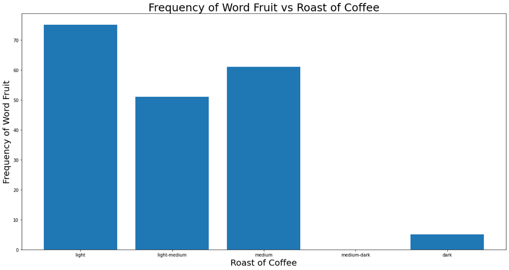

```python
generate_graph_for_words(['fruit'])
```

This seems more like what I expected from coffee, the word fruit seems to lean heavily toward the light and medium coffee roasts.

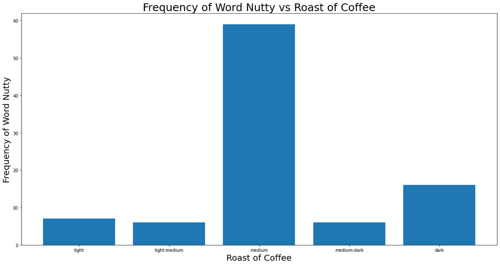

```python
generate_graph_for_words(['nutty'])
```

Again this is surprising to me. It seems like the things that I typically thought were used by dark coffees are really more like medium coffees. Let's try one more word that should be heavily attributed to dark coffees and see what the graph looks like before making final conclusions.

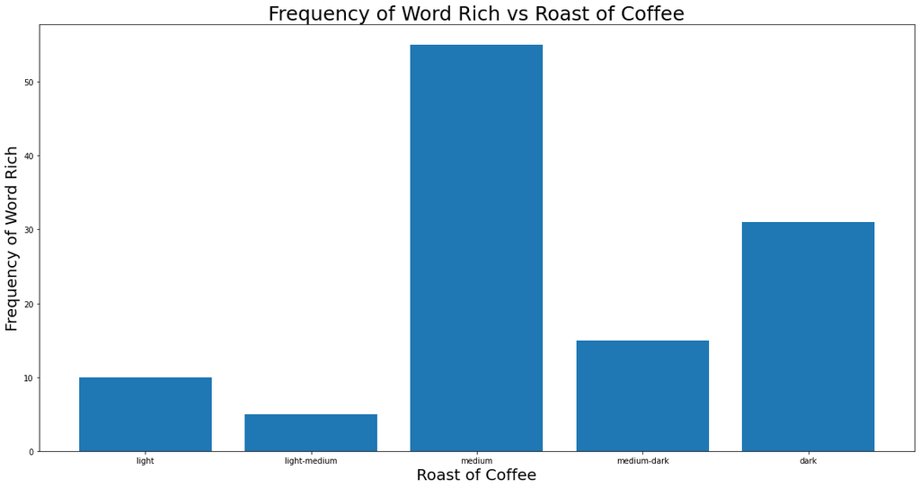

```python
generate_graph_for_words(['rich'])
```

Again I am surprised here! Something that I really should have checked before doing this is the distribution of different coffees. That could explain the reason why medium coffee seems overrepresented in all of these different graphs that should lean toward medium and dark roasts.

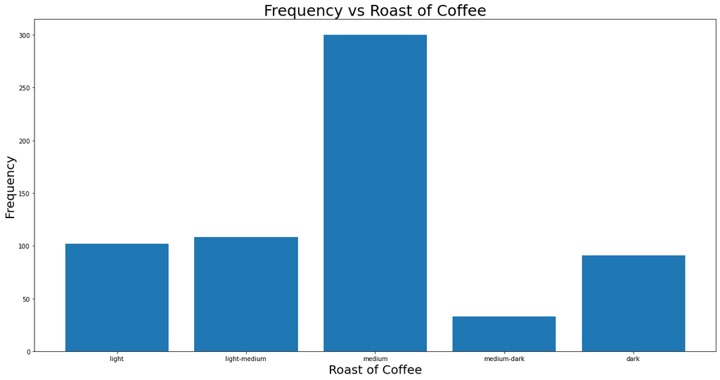

```python
count = [0, 0, 0, 0, 0]
possible_labels = ['light', 'light-medium', 'medium', 'medium-dark', 'dark']

# Count how many times the different coffees appear
for x, y in zip(data, labels):
    count[possible_labels.index(y)] += 1

# Plot the findings
fig = plt.figure(figsize=(20,10))
plt.bar(possible_labels,count)
plt.ylabel(f'Frequency', fontsize=20)
plt.xlabel('Roast of Coffee', fontsize=20)
plt.title(f'Frequency vs Roast of Coffee', fontsize=25)
plt.show()
```

Ahh this now makes a lot of sense! We can see that medium coffee is way more popular on this website than other roasts of coffee so it appears more in our graphs! Lets try making that function again, but this time looking at the relative frequency.

```python
# Plot different words relative frequency for differernt roasts of coffee
def generate_graph_for_words_relative(words):
    graph = [0, 0, 0, 0, 0]
    possible_labels = ['light', 'light-medium', 'medium', 'medium-dark', 'dark']

    # Count how many times word appears for different roast
    for x, y in zip(data, labels):
        for word in words:
            if word in x:
                graph[possible_labels.index(y)] += 1
                break

    # Divide by total count for roast
    for i in range(len(graph)):
        graph[i] /= count[i]

    # Plot
    fig = plt.figure(figsize=(20,10))
    plt.bar(possible_labels,graph)
    plt.ylabel(f'Frequency of Word{"s" if len(words) > 1 else ""} {", ".join([x.capitalize() for x in words])}', fontsize=20)
    plt.xlabel('Roast of Coffee', fontsize=20)
    plt.title(f'Relative Frequency of Word{"s" if len(words) > 1 else ""} {", ".join([x.capitalize() for x in words])} vs Roast of Coffee', fontsize=25)
    plt.show()
```

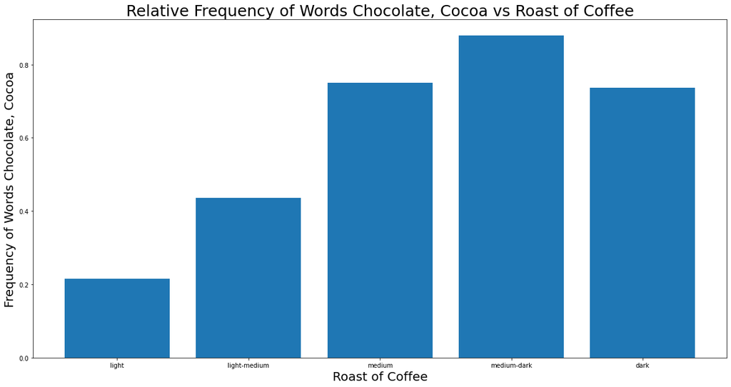

```python
generate_graph_for_words_relative(['chocolate', 'cocoa'])
```

This is not perfect, but is a lot more like what I expected to see (and it is a nice looking graph). We can see that the words chocolate and cocoa appear most frequently in medium-dark coffee but also appear frequently in dark and medium coffee and even sometimes in light-medium and light coffee.

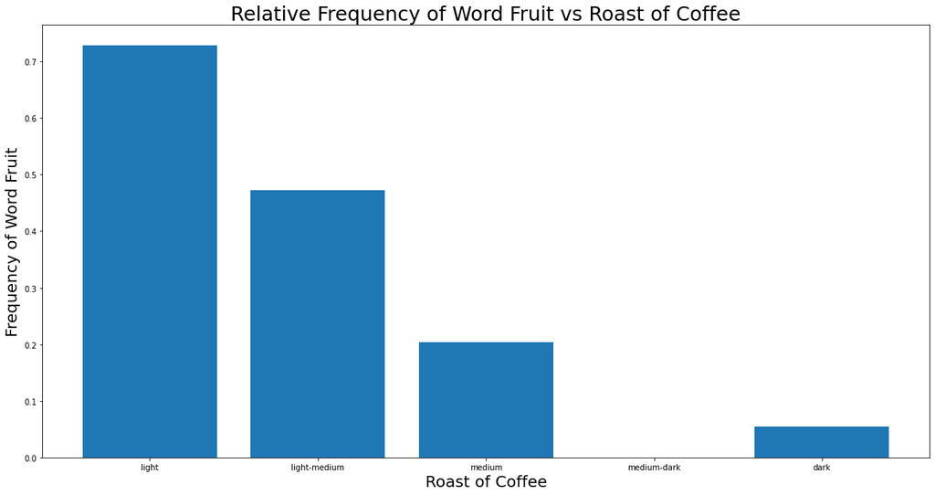

```python
generate_graph_for_words_relative(['fruit'])
```

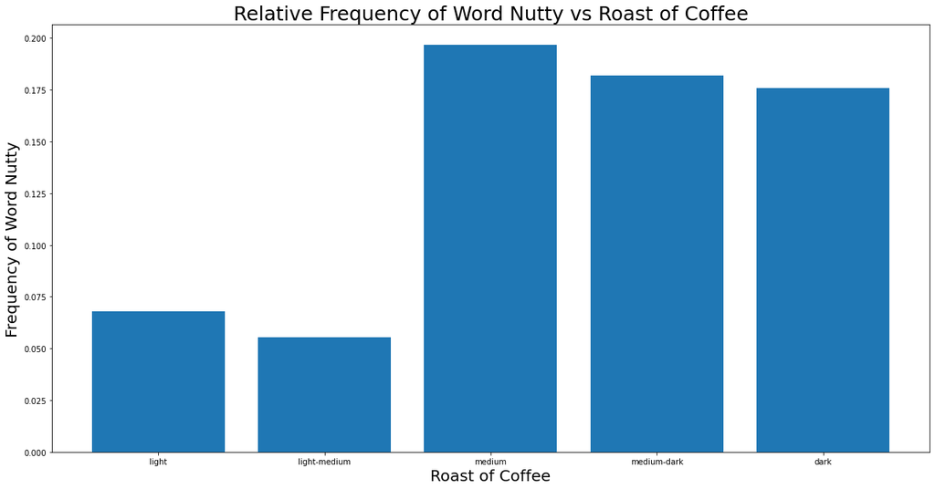

```python
generate_graph_for_words_relative(['nutty'])
```

We can see that medium-dark and dark coffee is much better represented here, however, this word would not be a good tf-idf word since it really could be any of the 3 right hand side roasts.

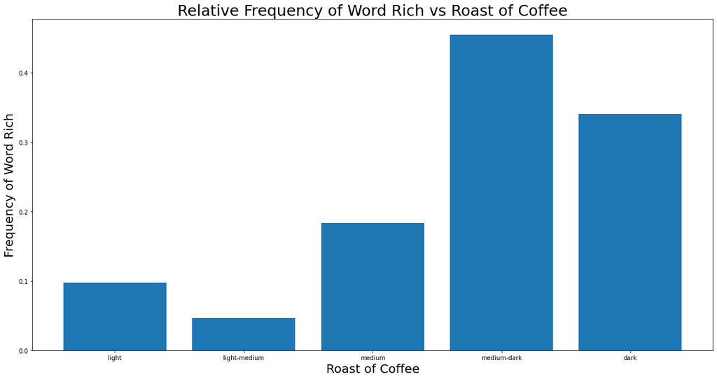

```python
generate_graph_for_words_relative(['rich'])
```

This is again much improved, it seems that the word rich is a pretty good indicator of corresponding to a medium-dark or dark roast coffee.

## tf-idf vs Doc2vec

Now that we have done some fun EDA, lets get into the really fun stuff, tfidf vs Doc2vec. After looking at the graphs above, I am pretty concerned about their performance. I really thought that there was going to be specific words that more obviously corresponded to different roasts of coffee, but that did not exactly seem to be the case.

## tf-idf

```python
from sklearn.feature_extraction.text import TfidfVectorizer
```

```python
# Split into train and test for initial test
train_x, train_y = data[:400], labels[:400]
test_x, test_y = data[400:], labels[400:]

# Fit on test data
vectorizer = TfidfVectorizer()
X = vectorizer.fit_transform(train_x).toarray()

# Now check accuracy of test data
correct = 0
for x, y in zip(test_x, test_y):
    test_vec = vectorizer.transform([x]).toarray()
    temp = X.dot(test_vec.T)

    for mat in temp.T:
        temp2 = [(train_y[i], x) for i, x in enumerate(mat)]
        if sorted(temp2, key=lambda i: i[1], reverse=True)[0][0] == y:
            correct += 1

print(f'accuracy = {correct/len(test_y)}')
```

```
accuracy = 0.43162393162393164
```

This is really not too bad a result for tf-idf. I was expecting a lot higher initially, but after seeing the graphs for different words, I was not expecting that high of an accuracy.

## Doc2vec

Now lets try Doc2vec. I have higher hopes for this model after seeing how Word2vec is able to group words based on meaning. My hope is that Doc2vec is able to group documents based on coffee roast.

```python
# Need a few more dependencies here
!pip install gensim
!pip install nltk
from gensim.test.utils import common_texts
from gensim.models.doc2vec import Doc2Vec, TaggedDocument
from nltk.tokenize import word_tokenize
import nltk
nltk.download('punkt')
```

[output not shown]

```
True
```

```python
# Split into initial train/test data
train_x, train_y = data[:400], labels[:400]
test_x, test_y = data[400:], labels[400:]

# Train the Doc2Vec model
tagged_data = [TaggedDocument(words=word_tokenize(_d.lower()), tags=[str(i)]) for i, _d in enumerate(train_x)]
model = Doc2Vec(tagged_data)


# Now check accuracy of test data
correct = 0
for x, y in zip(test_x, test_y):
    test = word_tokenize(x)
    ivec = model.infer_vector(test)
    g = model.dv.most_similar(positive=[ivec], topn=1)
    if train_y[int(g[0][0])] == y:
        correct += 1

print(f'accuracy = {correct/len(test_y)}')
```

```
accuracy = 0.3247863247863248
```

This accuracy is a little disappointing as I was expecting it to surpass tf-idf. However, this could just be an unlucky train/test split for Doc2vec. To really see which model is better, I am going to split the data 10 times randomly using a 2/3 train 1/3 test split. Then I will evaluate the accuracy for each iteration and average over the accuracies to get a better picture of these models' performances.

```python
from sklearn.model_selection import train_test_split
```

```python
acc_tfidf = []
acc_doc2vec = []

for i in range(10):
    # 2/3 1/3 split
    X_train, X_test, y_train, y_test = train_test_split(data, labels, test_size=0.33)

    # train and test tfidf
    vectorizer = TfidfVectorizer()
    X = vectorizer.fit_transform(X_train).toarray()

    # Now check accuracy of test data
    correct = 0
    for x, y in zip(X_test, y_test):
        test_vec = vectorizer.transform([x]).toarray()
        temp = X.dot(test_vec.T)

        for mat in temp.T:
            temp2 = [(y_train[i], x) for i, x in enumerate(mat)]
            if sorted(temp2, key=lambda i: i[1], reverse=True)[0][0] == y:
                correct += 1

    acc_tfidf.append(correct/len(test_y))

    # train and test doc2vec
    tagged_data = [TaggedDocument(words=word_tokenize(_d.lower()), tags=[str(i)]) for i, _d in enumerate(X_train)]
    model = Doc2Vec(tagged_data)


    # Now check accuracy of test data
    correct = 0
    for x, y in zip(X_test, y_test):
        test = word_tokenize(x)
        ivec = model.infer_vector(test)
        g = model.dv.most_similar(positive=[ivec], topn=1)
        if y_train[int(g[0][0])] == y:
            correct += 1

    acc_doc2vec.append(correct/len(test_y))

print(f'Average tfidf acc = {sum(acc_tfidf)/10}')
print(f'Average Doc2Vec acc = {sum(acc_doc2vec)/10}')
```

```
Average tfidf acc = 0.3935897435897436
Average Doc2Vec acc = 0.27521367521367524
```

These are really not that great of performances, unfortunately. I am especially disappointed with Doc2vec's performance, however, it could be indicative of bad data for this type of model. Seeing that words like chocolate, which we would want to heavily correspond to a specific roast type, actually was spread almost evenly across 3 different roast types was not a good sign. In fact, I think if we had a classifier that predicted medium every time, it would be better than these for this specific data. Obviously, that would not generalize that well so it is a bad idea, but it is just something interesting to note. Overall, while I am not thrilled with my models' performance, I am still happy that I did this project as it was interesting and something that I have wanted to do for a long time.